# VINOS

Silvina Pichetto / Florencia Vuono

# *El presente informe presenta un ranking de vinos puntuados según la Revista Wine Esthusiast que cuenta con un equipo de revisores de cata más de 24 000 vinos de todo el mundo cada año, desde Francia e Italia hasta California, Australia, Sudáfrica, Argentina y más. Cuenta con acceso gratuito a la base de datos de calificaciones de vinos, cervezas y licores se puede filtrar por puntuación, precio, cosecha, variedad de uva y región, lo que lo convierte en una herramienta fácil y flexible para encontrar su bebida favorita.*

## Exploración de los datos

La base contiene 129.961 vinos puntuados, según país, precio, región, variedad, vina y contiene una pequeña reseña de cada uno.

```r
# Código para cargar o leer los datos
vinos <- read_csv("datos/vinos.csv")
```

Promedio de precios de vinos Cual es el precio promedio de la lista de vinos? El precio promedio es de 35.36

```r
vinos %>%
  summarise(precio_promedio = mean(precio, na.rm = TRUE))
```

```
## # A tibble: 1 × 1
##   precio_promedio
##             <dbl>
## 1            35.4
```

Vinos más caros, cuyo valor es superior a 400

```r
vinos_caros <- filter(vinos, precio >= 400)
```

Gráfico de vinos más caros por país.

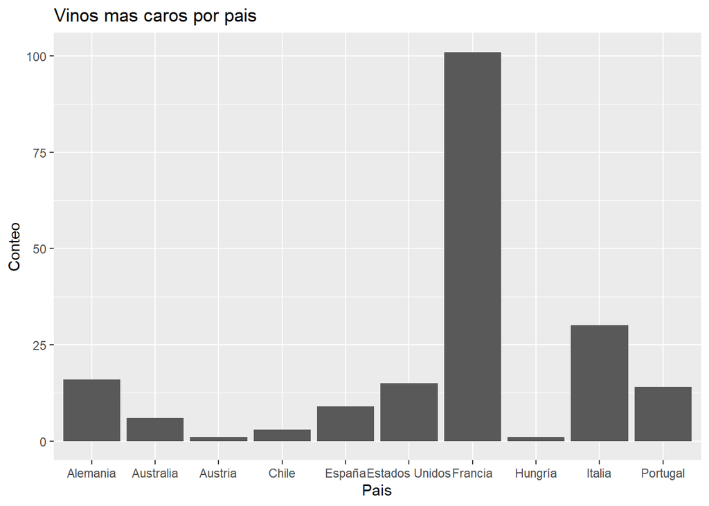

```r
vinos_caros %>%
  ggplot(aes(x = pais)) +
  geom_bar() +
  labs(title = "Vinos mas caros por pais",
       x = "Pais",
       y = "Conteo")
```

Aquí podemos ver que los vinos más caros provienen, principalmente de Francia.

Ahora vamos a realmente comprobar si los vinos más caros provienen de Francia, o es porque éstos tienen más reviews.

```r
conteo_resenas <- vinos %>%
  count(pais)
```

```r
print(conteo_resenas)
```

```
## # A tibble: 44 × 2
##    pais                     n
##    <chr>                <int>
##  1 Alemania              2165
##  2 Argentina             3800
##  3 Armenia                  2
##  4 Australia             2329
##  5 Austria               3345
##  6 Bosnia y Herzegovina     2
##  7 Brazil                  52
##  8 Bulgaria               141
##  9 Canadá                 257
## 10 Chile                 4472
## # ℹ 34 more rows
```

Podemos ver que hay un sesgo en la base de datos porque hay paises que tienen más reviews que otros. En este caso Francia tiene 22093 reviews de vinos.

Ahora vamos a explorar vinos con precios muy baratos.

Vinos baratos, cuyo un valor es inferior <=4. En principio y a simple vista podemos ver que 11 vinos cumplen con la variable, vinos baratos. Pero si normalizamos la cantidad de vinos baratos por la cantidad total de reviews, obtenemos la proporcion de vinos baratos que realmente cumplen con la condición.

```r
# Filtrar vinos baratos
vinos_baratos <- filter(vinos, precio <= 4)

# Calcular cantidad total de reseñas
total_resenas <- nrow(vinos)

# Calcular cantidad de reseñas de vinos baratos
resenas_vinos_baratos <- nrow(vinos_baratos)

# Calcular proporción de reseñas de vinos baratos
proporcion_vinos_baratos <- resenas_vinos_baratos / total_resenas

# Imprimir la proporción
print(proporcion_vinos_baratos)
```

```
## [1] 8.463426e-05
```

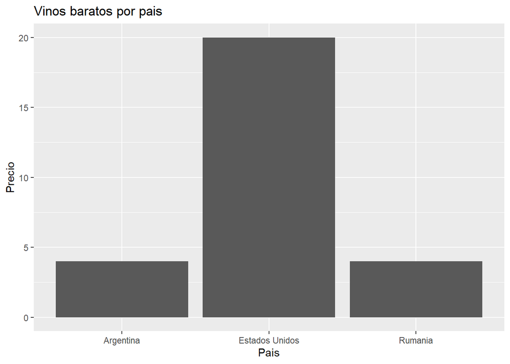

```r
vinos_baratos %>%
  filter(pais %in% c("Espana", "Estados Unidos", "Rumania", "Argentina")) %>%
  ggplot(aes(x = pais, y = precio)) +
  geom_bar(stat = "identity") +
  labs(title = "Vinos baratos por pais",
       x = "Pais",
       y = "Precio")
```

Podemos ver que los vinos baratos provienen principalmente de Estados Unidos.

Vinos mejor puntuados, cuya puntuación es 100

```r
vinos_mejor_puntuados <- filter(vinos, puntos == 100)
```

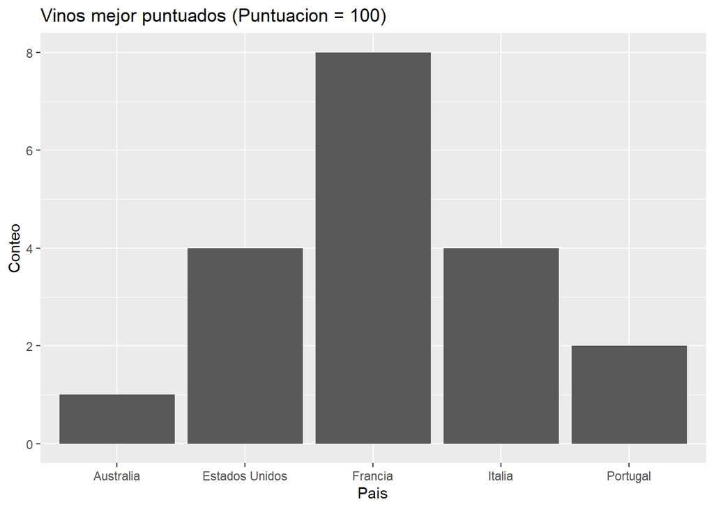

```r
vinos_mejor_puntuados %>%
  ggplot(aes(x = pais)) +
  geom_bar() +
  labs(title = "Vinos mejor puntuados (Puntuacion = 100)",
       x = "Pais",
       y = "Conteo")
```

De qué provincia provienen los mejores vinos puntuados de Argentina ?

```r
mejores_vinos_argentina <- subset(vinos, pais == "Argentina" & puntos >= 95)
```

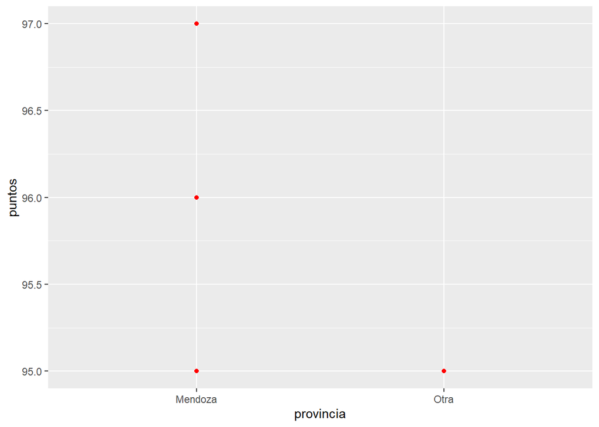

```r
ggplot(mejores_vinos_argentina, aes(x = provincia, y = puntos)) +
  geom_point(color = "red")
```

Ahora vamos a ver los vinos mejor puntuados (>= de 95 puntos) por debajo del promedio de precio, osea 35.

```r
Vinos_puntos_precio<- filter(vinos,puntos >=95, precio<=35)
```

Tomando esta última variable que creamos, vamos a agrupar por país y descubrir cuales son los países productores de estos vinos económicos y mejor puntuados. Cual es el mejor país dentro de este Ranking?

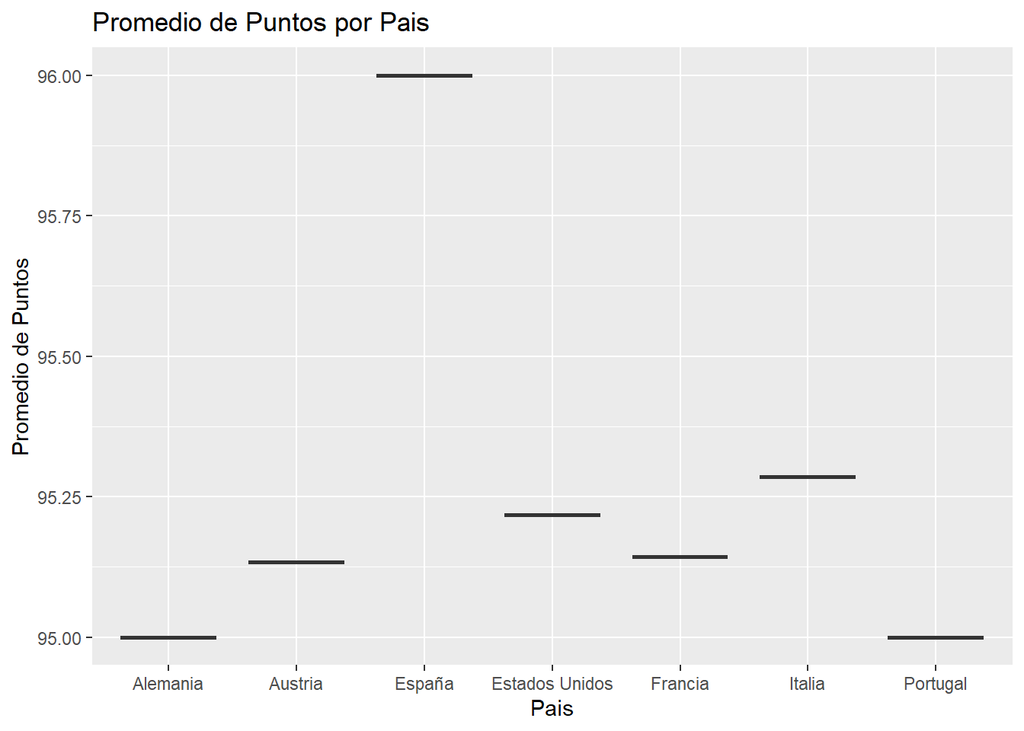

```r
Vinos_puntos_precio %>%
  group_by(pais) %>%
  summarise(promedio_puntos = mean(puntos, na.rm = TRUE)) %>%
  ggplot(aes(pais, promedio_puntos)) +
  geom_boxplot(fill = "steelblue") +
  labs(x = "Pais", y = "Promedio de Puntos") +
  ggtitle("Promedio de Puntos por Pais")
```

El pais con mejores vinos y detro del precio promedio es España con 96.

Ahora vamos a ver cómo viene Argentina en el ranking de precio y calidad…tiene nuestro país vinos que estén económicos por debajo del precio promedio y con buena puntuación?

```r
Vinos_argentina<- filter(vinos,pais == "Argentina", precio<=35, puntos >= 93 )
```

Argentina tiene 7 vinos que cumplen con el promedio de precio y con una buena puntuación de 93. No tienen ninguno que cumpla con ambas condiciones de estar igual o por debajo del promedio general de 35 y con puntaje de 95.

Cual es el promedio de Precios de los vinos de Argentina?

```r
Vinos_argentina %>%
  group_by(pais) %>%
  summarise(mean_precio = mean(precio, na.rm = TRUE),
            mean_puntos = mean(puntos, na.rm = TRUE))
```

```
## # A tibble: 1 × 3
##   pais      mean_precio mean_puntos
##   <chr>           <dbl>       <dbl>
## 1 Argentina        30.3          93
```

Vemos que Argentina tiene un promedio de 93 puntos y precio por debajo del promedio de vinos, 30. Asi que podemos decir que en Argentina se consiguen vinos muy buen puntuados por debajo del precio promedio de la lista analizada.

## Hipótesis

La variedad de malbec de la Provincia de Mendoza está entre las mejores puntuadas de Argentina y del mundo.

```r
subset(vinos, pais == "Argentina" & variedad == "Malbec" & puntos>= 94)
```

```
## # A tibble: 37 × 10
##    pais      nombre     puntos precio provincia region_1 region_2 variedad vina
##    <chr>     <chr>       <dbl>  <dbl> <chr>     <chr>    <chr>    <chr>    <chr>
##  1 Argentina Terroir S…     94     55 Mendoza   Uco Val… <NA>     Malbec   Trap…
##  2 Argentina Single Vi…     94     48 Mendoza   Luján d… <NA>     Malbec   Alta…
##  3 Argentina Single Vi…     94     48 Mendoza   Luján d… <NA>     Malbec   Alta…
##  4 Argentina Bramare M…     94     90 Mendoza   Luján d… <NA>     Malbec   Viña…
##  5 Argentina Bramare T…     94     90 Mendoza   Luján d… <NA>     Malbec   Viña…
##  6 Argentina Temis Sin…     94     50 Mendoza   Mendoza  <NA>     Malbec   Alta…
##  7 Argentina Bramare M…     94     90 Mendoza   Mendoza  <NA>     Malbec   Viña…
##  8 Argentina Finca Bel…     94    140 Mendoza   Mendoza  <NA>     Malbec   Acha…
##  9 Argentina Finca Mir…     94    140 Mendoza   Mendoza  <NA>     Malbec   Acha…
## 10 Argentina Paraje Al…     94     60 Mendoza   Mendoza  <NA>     Malbec   Seed
## # ℹ 27 more rows
## # ℹ 1 more variable: titulo_resena <chr>
```

Podemos encontrar 37 vinos malbec con una puntuación de 94.

La variable vinos caros no siempre se relaciona con la variable de mejor puntuados, se pueden encontrar vinos con precio barato con buena puntuacion.

```r
filter(vinos,precio <=18, puntos>=94)
```

```
## # A tibble: 9 × 10
##   pais           nombre puntos precio provincia region_1 region_2 variedad vina
##   <chr>          <chr>   <dbl>  <dbl> <chr>     <chr>    <chr>    <chr>    <chr>
## 1 Estados Unidos Lucil…     94     18 Washingt… Yakima … Columbi… Viognier Stot…
## 2 España         Pedro…     94     14 Andalucía Jerez    <NA>     Sherry   Osbo…
## 3 Portugal       Assob…     94     13 Douro     <NA>     <NA>     Portugu… Quin…
## 4 Francia        Symph…     94     18 Southwes… Jurançon <NA>     Petit M… Doma…
## 5 Estados Unidos Secco      94     16 Californ… Lodi     Central… Moscato… Uvag…
## 6 Estados Unidos Estate     94     18 Oregon    Willame… Willame… Riesling Davi…
## 7 Austria        Vm Be…     94     18 Kamptal   <NA>     <NA>     Riesling Eich…
## 8 Estados Unidos Dijon…     94     18 Californ… Sonoma … Sonoma   Chardon… Jose…
## 9 Estados Unidos Petit…     94     18 Californ… Lodi     Central… Petite … Mich…
## # ℹ 1 more variable: titulo_resena <chr>
```

Se puede confirmar que se encuentran vinos baratos, con buena puntuacion.

Cual es el país que posee el mejor promedio?

```r
promedio_puntos_pais <- vinos %>%
  group_by(pais) %>%
  summarise(promedio_puntos = mean(puntos, na.rm = TRUE))
```

Inglaterra es el país que tiene el mejor promedio de vinos puntuados, 91.58.